[figure not shown]

12/13/2019

William Entz  
10178 County Street 2460  
Hydro, OK,

To Whom It May Concern:

Thank you for participating in the Oklahoma Groundwater Monitoring and Assessment Program (GMAP) with the Oklahoma Water Resources Board (OWRB). Your well, located in the NE quarter of 34-12N-13WI, of the Rush Springs aquifer was sampled on 08/05/2019. Enclosed, are the results of the sampling.

Included in this packet is a copy of the laboratory analysis of your water well outlining the analyzed parameters and their respective value. Next to the results, you will also find the corresponding U.S. Environmental Protection Agency’s (USEPA): Primary Maximum Contaminant Levels (MCL), Secondary Maximum Contaminant Levels (SMCL) and health advisories. Please note that these screening levels are issued for public drinking water supplies. For more information about these contaminant levels please visit the additional resources listed on the results page. If you have questions or concerns about the results from your well, please contact the Department of Environmental Quality at (800) 869-1400 or visit their website [www.deq.state.ok.us].

The water quality data from this year’s GMAP sampling will be available on our website within the upcoming months. We invite you to visit the Water Quality Monitoring page at [www.owrb.ok.gov] for more information on this program’s progress and results. The OWRB appreciates your willingness to participate in the GMAP program. If you have any further questions for the OWRB, you may contact me by email at Margarita.Mendivelso@owrb.ok.gov or by telephone at (405) 530-8800.

Sincerely,

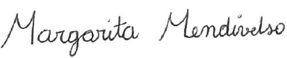

Margarita Mendivelso,  
Environmental Programs Manager  
Water Quality Programs Division

[figure not shown]

[figure not shown]

Groundwater Monitoring & Assessment Program

Well Analysis Results

This well is registered with OWRB as well **4599** and is within, or geochemically influenced, by the Rush Springs aquifer. This data was collected on 08/05/2019. During collection all water was filterd and so the data is representative of the dissolved water chemistry. The total concentration of any parameter may be greater than that recorded here.

Alkalinity: 172 mg/L.  
Hardness: 307 mg/L.  
Depth to water below ground surface: 36.27 feet.

### Primary Maximum Contaminant Levels

The EPA has set National Primary Drinking Water Regulations, called Maximum Contaminant Levels (MCL) to protect the pulic against consumption of drinking water contaminants that present a risk to **human health**. The MCLs and the analytical results from well 4599 are in **Table 1** below:

**Table 1:** Analytical results and EPA Primary MCL values. Green result values with down arrows indicate results are below the MCL. Red values with up arrows indicate results are above the MCL. A “<” symbol indicates the result value is below the laboratory reporting limit.

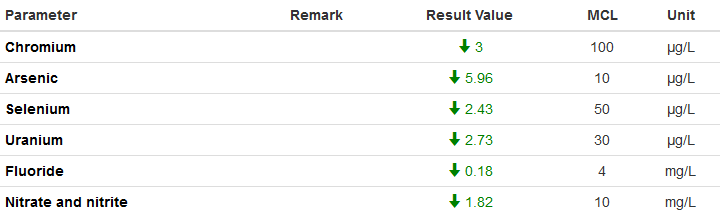

### Secondary Maximum Contaminant Levels

The EPA has set non-mandatory National Secondary Drinking Water Regulations, called Secondary Maximum Contaminant Levels, to assist public water systems in managing thier drinking water for **aesthetic** considerations such as taste, color, and odor. These contaminants are **NOT** considered to present a risk to human health at the SMCL. The SMCLs and the analytical results from well 4599 are in **Table 2** below:

**Table 2:** Analytical results and EPA Primary SMCL values. Green result values with down arrows indicate results are below the SMCL. Red values with up arrows indicate results are above the SMCL. A “<” symbol indicates the result value is below the laboratory reporting limit.

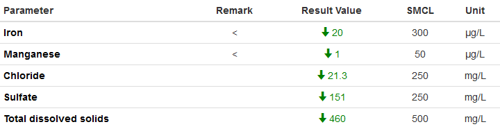

### EPA Health Advisories

The EPA has issued additional **health advisories** for some parameters in drinking water. These health advisory values and the analytical results from well 4599 are in **Table 3** below:

**Table 3:** Analytical results and EPA Health Advisory values. Green result values with down arrows indicate results are below the Health Advisory. Red values with up arrows indicate results are above the Health Advisory. A “<” symbol indicates the result value is below the laboratory reporting limit.

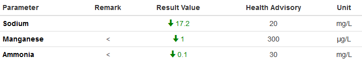

### General Analytical Results

GMAP also analyzes a number of general parameters for which the EPA **does not regulate** and has **no guidelines**. These analytical resutls can be found in **Table 4** below:

**Table 4:** Analytical results for non-regulated parameters. A “<” symbol indicates the result value is below the laboratory reporting limit.

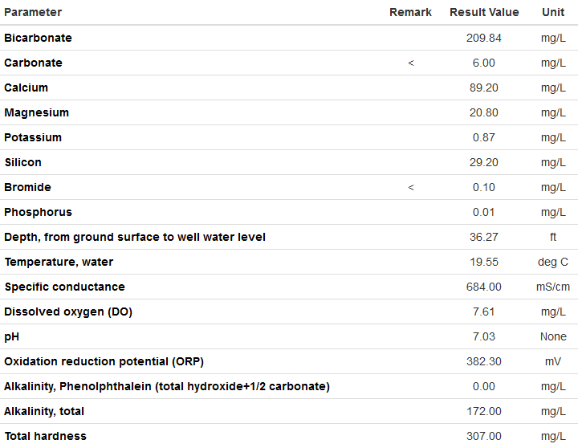

### Further Information

Please visit the following sites for additional information on water quality guidelines:  
https://www.epa.gov/sites/production/files/2016-06/documents/npwdr_complete_table.pdf  
https://www.epa.gov/ground-water-and-drinking-water/national-primary-drinking-water-regulations  
https://www.epa.gov/safewater  
http://www.owrb.ok.gov/quality/monitoring/monitoring.php